importujemy biblioteki

```python
import pandas as pd
import matplotlib.pyplot as plt
```

tworzymy listy wartości pobranych ze stat.gov.pl

```python
rok=['2004','2005','2006','2007','2008','2009','2010','2011','2012','2013','2014','2015','2016']
dochody=[2409.69,2506.93,2636.81,2866.04,3158.48,3315.38,3435.00,3625.21,3744.38,3877.43,4003.99,4150.88,4290.52]
wodka=[20.80,19.62,18.41,18.09,18.61,19.50,19.59,19.90,20.27,20.37,21.67,25.06,24.55]
fajki=[4.88,5.26,5.6,5.99,6.72,8.03,9.24,10.21,11.27,11.96,12.48,12.82,13.40]
benzyna=[3.76,4.03,4.00,4.25,4.36,4.18,4.59,5.14,5.73,5.51,5.30,4.65,4.37]
```

tworzymy z nich 1 listę i wyświetlamy ją

```python
baza = { 'rok':rok, 'dochod':dochody, 'wodka':wodka, 'papierosy':fajki, 'benzyna':benzyna }
baza
print(baza)
```

[output not shown]

tworzymy i wyświetlamy dataframe

```python
df = pd.DataFrame(baza)
df
```

|  | benzyna | dochod | papierosy | rok | wodka |
| --- | --- | --- | --- | --- | --- |
| 0 | 3.76 | 2409.69 | 4.88 | 2004 | 20.80 |
| 1 | 4.03 | 2506.93 | 5.26 | 2005 | 19.62 |
| 2 | 4.00 | 2636.81 | 5.60 | 2006 | 18.41 |
| 3 | 4.25 | 2866.04 | 5.99 | 2007 | 18.09 |
| 4 | 4.36 | 3158.48 | 6.72 | 2008 | 18.61 |
| 5 | 4.18 | 3315.38 | 8.03 | 2009 | 19.50 |
| 6 | 4.59 | 3435.00 | 9.24 | 2010 | 19.59 |
| 7 | 5.14 | 3625.21 | 10.21 | 2011 | 19.90 |
| 8 | 5.73 | 3744.38 | 11.27 | 2012 | 20.27 |
| 9 | 5.51 | 3877.43 | 11.96 | 2013 | 20.37 |
| 10 | 5.30 | 4003.99 | 12.48 | 2014 | 21.67 |
| 11 | 4.65 | 4150.88 | 12.82 | 2015 | 25.06 |
| 12 | 4.37 | 4290.52 | 13.40 | 2016 | 24.55 |

Sprawdzamy dla jakich lat występowało ryzyko alkoholizmu(cena pół litra wódki poniżej 20zł):

- Pobieramy kolumnę z cenami wódki
- Zapisujemy lata w których cena była poniżej 20zł
- Tworzymy nowy dataframe
- Prezentujemy kolumnę z latami w których występuje ryzyko alkoholizmu

```python
cena_wodki = df['wodka']
tania = cena_wodki < 20
alkoholizm = df[tania]
alkoholizm[['rok']]
```

|  | rok |
| --- | --- |
| 1 | 2005 |
| 2 | 2006 |
| 3 | 2007 |
| 4 | 2008 |
| 5 | 2009 |
| 6 | 2010 |
| 7 | 2011 |

Sprawdźmy na wykresie czy występują jakieś zależności pomiędzy analizowanymi wartościami. Czy ceny za poszczególne produkty wzrastały równomiernie?

- Wyznaczamy rozmiar wykresu
- Wybieramy dataframe które zaprezentujemy na wykresie
- Dodajemy legendę do wykresu
- Dodajemy opis do osi Y
- Prezentujemy wykres

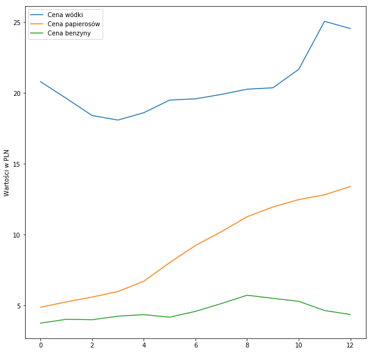

```python
plt.figure(figsize=(10,10))

plt.plot(df['wodka'])
plt.plot(df['papierosy'])
plt.plot(df['benzyna'])

plt.legend(['Cena wódki', 'Cena papierosów', 'Cena benzyny'], loc='upper left')

plt.ylabel('Wartości w PLN')

plt.show()
```

Ciekawie wydaje się wyglądać zależność pomiędzy cenami używek, wódki i papierosów. Sprawdźmy jak na przestrzeni lat wyglądała zdolność do zakupu używek przez osobę ze średnią pensją krajową

- Dla czytelności zmieniamy rozmiar wykresu
- Dodajemy wartość dochodów w danym roku, podzieloną przez śednią cenę 0.5 litra wódki
- To samo dla paczki papierosów
- Dodajemy legendę
- Dodaje opisy do osi X i Y
- Tworzymy nową listę tick_value
- Ustawiamy ilość jej elementów na długość dataframeu rok
- Zapisujemy wartości df rok do zmiennej tick_label
- Dodajemy ilość i opisy do poszczególnych punktów na osi X
- I pokazujemy wykres

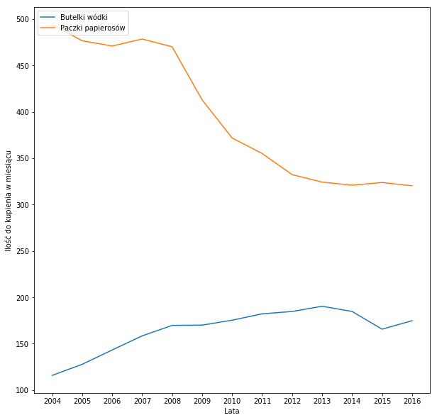

```python
plt.figure(figsize=(10,10))

plt.plot(df['dochod']/df['wodka'])
plt.plot(df['dochod']/df['papierosy'])

plt.legend(['Butelki wódki', 'Paczki papierosów'], loc='upper left')

plt.ylabel('Ilość do kupienia w miesiącu')
plt.xlabel('Lata')

tick_value=[]
tick_value= range(len(df['rok']))
tick_label=df['rok']

plt.xticks(tick_value, tick_label)

plt.show()
```

Widać więc, że na przestrzeni lat możliwości zakupu przez osobę o średniej krajowej: